# CellMixture SIGURD

2024-09-26

## Cell Mixture Analysis using SIGURD

Here, we reproduce the results from the MAESTER script 3.1_SW_CellLineMix_variants.R.

It is available here: https://github.com/petervangalen/MAESTER-2021/blob/main/3_Cell_line_mixes_variants/3.1_SW_CellLineMix_variants.R

In this data set, chronic myelogenous leukemia cells (K562) and brain tumor cells (BT142) were mixed and then sequenced using Seq-Well S3. The cells can be separated using the expression of marker genes.

The original script then identifies 6 variants that can distinguish between the two cell types.

The analysis was repeated by Miller et al using the 10x Genomics v3 protocol. This was performed in the script 3.3_TenX_CellLineMix_variants.R. Available here: https://github.com/petervangalen/MAESTER-2021/blob/main/3_Cell_line_mixes_variants/3.3_TenX_CellLineMix_variants.R

Both approaches produced similar results and we are able to reproduce them. We show case the reproduction of the Seq-Well results, since these results were shown in the main figure 1.

In this reproduction, we show that the analysis can be faithfully reproduced using a very streamlined set of functions. This greatly simplifies the analysis. Using a set of dedicated functions, the analysis can now also be easily adopted to new data sets.

## Loading necessary packages.

We load the data from MAESTER.

```r
print("Libraries for SIGURD.")
```

```
## [1] "Libraries for SIGURD."
```

```r
suppressPackageStartupMessages(library(sigurd))
suppressPackageStartupMessages(library(SummarizedExperiment))
suppressPackageStartupMessages(library(ggplot2))
```

## We load the Seurat object for the scRNA-seq data.

```r
seu <- readRDS("SW_CellLineMix_Seurat_Keep.rds")
```

## Loading the data using SIGURD.

SIGURD loads the data and automatically reformats the data. This code uses dedicated functions to load the and process the data, which streamlines the analysis quite substantially.

```r
# The design matrix contains information for the genotyping data.
genotyping <- LoadingMAEGATK_typewise(patient = "SW", samples_file = "MAESTER_Reproduction.csv", min_cells = 0, type_use = "Amplicon_MT", verbose = FALSE)

# Removing cells that are not in the Seurat object.
genotyping <- Filtering(genotyping, cells_include = colnames(seu))
```

```
## [1] "We remove all cells not in the allow list."
## [1] "We remove all the variants that are always NoCall."
```

```r
# Adding meta data do the SIGURD object.
colData(genotyping)$CellType <- seu$CellType

# Saving the genotyping object.
save_object(genotyping, "SW_CellMixture_Genotyping.rds.lz4", "lz4")
```

## Selecting the Variants of Interest

Now, we select the variants of interest.

```r
# Selecting informative variants.
voi.ch.sigurd <- VariantSelection_Quantile(genotyping, min_coverage = 20, min_quality = 30, quantiles = c(0.1, 0.9), thresholds = c(0.1, 0.9), verbose = FALSE)
print(voi.ch.sigurd)
```

```
## [1] "chrM_709_G_A"  "chrM_1888_G_A" "chrM_1420_T_C" "chrM_2141_T_C"
## [5] "chrM_9117_T_C" "chrM_7990_C_T"
```

## Visualisation using SIGURD

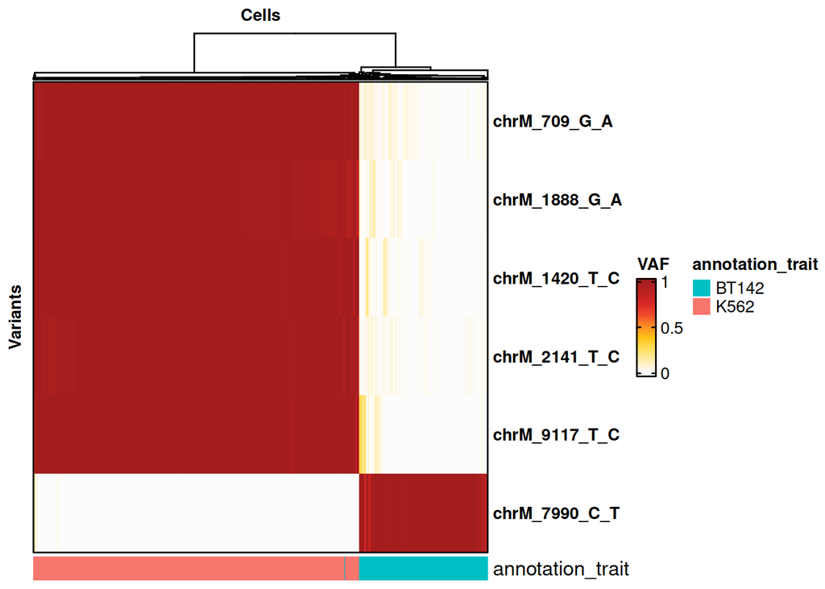

```r
# Determining if a cell is supporting one of the two cell types.
cell_support <- CallSupport(SE = genotyping, VOI_group1 = c("chrM_709_G_A", "chrM_1888_G_A", "chrM_1420_T_C", "chrM_2141_T_C", "chrM_9117_T_C"), VOI_group2 = "chrM_7990_C_T", group1_name = "K562", group2_name = "BT142", min_mutated_reads = 3, min_reads = 30, group_factor = 10, verbose = FALSE)

# Plotting the results on a heatmap.
HeatmapVoi(SE = genotyping[,cell_support$Cell], voi = voi.ch.sigurd, annotation_trait = "CellType", minimum_coverage = 3, remove_empty_cells = FALSE)
```